# Estudis d'Informàtica, Multimedia i Telecomunicacions

# Mineria de dades: PEC2 - Mètodes no supervisats

Autor: Arnau Garcia Rodríguez

Novembre 2023

# 1 Exercici 1

Presenta el joc de dades, nom i significat de cada columna, així com les distribucions dels seus valors.

Realitza un estudi aplicant el mètode K-means, similar al dels exemples 1.1 i 1.2

## 1.1 Resposta 1

```r
set.seed(2)
```

Utilitzarem un joc de dades anomenat Hawks (paquet Stat2Data) amb informació sobre falcons. Les dades són un subconjunt de les originals, que van ser recollides per estudiants i professors del Cornell College a Mount Vernon, Iowa.

A continuació, s’importa el joc de dades i es mostra un resum de cadascuna de les característiques:

```r
if (!require('Stat2Data')) install.packages('Stat2Data'); library('Stat2Data')
data("Hawks")
summary(Hawks)
```

```
##      Month             Day             Year       CaptureTime   ReleaseTime
##  Min.   : 8.000   Min.   : 1.00   Min.   :1992   11:35  : 14          :842
##  1st Qu.: 9.000   1st Qu.: 9.00   1st Qu.:1995   13:30  : 14   11:00  :  2
##  Median :10.000   Median :16.00   Median :1999   11:45  : 13   11:35  :  2
##  Mean   : 9.843   Mean   :15.74   Mean   :1998   12:10  : 13   12:05  :  2
##  3rd Qu.:10.000   3rd Qu.:23.00   3rd Qu.:2001   14:00  : 13   12:50  :  2
##  Max.   :11.000   Max.   :31.00   Max.   :2003   13:05  : 12   13:32  :  2
##                                                  (Other):829   (Other): 56
##       BandNumber  Species  Age     Sex          Wing           Weight
##            :  2   CH: 70   A:224    :576   Min.   : 37.2   Min.   :  56.0
##  1142-09240:  1   RT:577   I:684   F:174   1st Qu.:202.0   1st Qu.: 185.0
##  1142-09241:  1   SS:261           M:158   Median :370.0   Median : 970.0
##  1142-09242:  1                            Mean   :315.6   Mean   : 772.1
##  1142-18229:  1                            3rd Qu.:390.0   3rd Qu.:1120.0
##  1142-19209:  1                            Max.   :480.0   Max.   :2030.0
##  (Other)   :901                            NA's   :1       NA's   :10
##      Culmen         Hallux            Tail        StandardTail
##  Min.   : 8.6   Min.   :  9.50   Min.   :119.0   Min.   :115.0
##  1st Qu.:12.8   1st Qu.: 15.10   1st Qu.:160.0   1st Qu.:162.0
##  Median :25.5   Median : 29.40   Median :214.0   Median :215.0
##  Mean   :21.8   Mean   : 26.41   Mean   :198.8   Mean   :199.2
##  3rd Qu.:27.3   3rd Qu.: 31.40   3rd Qu.:225.0   3rd Qu.:226.0
##  Max.   :39.2   Max.   :341.40   Max.   :288.0   Max.   :335.0
##  NA's   :7      NA's   :6                        NA's   :337
##      Tarsus        WingPitFat        KeelFat           Crop
##  Min.   :24.70   Min.   :0.0000   Min.   :0.000   Min.   :0.0000
##  1st Qu.:55.60   1st Qu.:0.0000   1st Qu.:2.000   1st Qu.:0.0000
##  Median :79.30   Median :1.0000   Median :2.000   Median :0.0000
##  Mean   :71.95   Mean   :0.7922   Mean   :2.184   Mean   :0.2345
##  3rd Qu.:87.00   3rd Qu.:1.0000   3rd Qu.:3.000   3rd Qu.:0.2500
##  Max.   :94.00   Max.   :3.0000   Max.   :4.000   Max.   :5.0000
##  NA's   :833     NA's   :831      NA's   :341     NA's   :343
```

#### 1.1.0.1 Diccionari de les columnes

Prime, s’importa la llibreria **cluster**:

```r
if (!require('cluster')) install.packages('cluster')
library(cluster)
```

```r
x <- na.omit(Hawks[,10:13])
summary(x)
```

```
##       Wing           Weight           Culmen          Hallux
##  Min.   : 37.2   Min.   :  56.0   Min.   : 8.60   Min.   :  9.50
##  1st Qu.:202.0   1st Qu.: 185.0   1st Qu.:12.80   1st Qu.: 15.10
##  Median :370.0   Median : 970.0   Median :25.50   Median : 29.40
##  Mean   :315.9   Mean   : 771.6   Mean   :21.81   Mean   : 26.41
##  3rd Qu.:390.0   3rd Qu.:1120.0   3rd Qu.:27.35   3rd Qu.: 31.40
##  Max.   :480.0   Max.   :2030.0   Max.   :39.20   Max.   :341.40
```

Com no sabem el nombre idoni de clústers, provem amb diversos valors. Es pot observar una gràfica que conté informació sobre cadascun dels models resultants de k-means, com la suma dels quadrats de les distàncies dels punts de cadascun dels clústers respecte el centre (withinss). Seleccionarem el valor que es trobi al colze de la corba, on comença a estabilitzar-se i per més clústers que afegeixis la densitat de punts no varia de forma significativa.

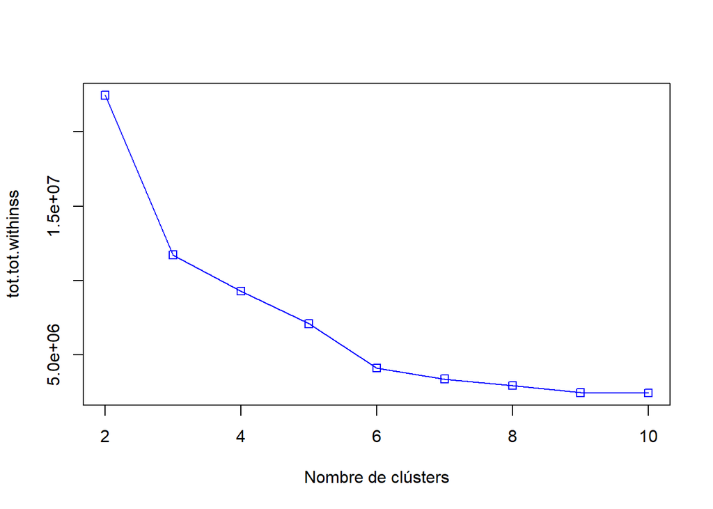

```r
resultados <- rep(0, 10)
for (i in c(2,3,4,5,6,7,8,9,10))
{
  fit           <- kmeans(x, i)
  resultados[i] <- fit$tot.withinss
}
plot(2:10,resultados[2:10],type="o",col="blue",pch=0,xlab="Nombre de clústers",ylab="tot.tot.withinss")
```

Per a corroborar aquest resultat, existeixen llibreries d’R que ens poden ajudar. Podem utilitzar el mètode *kmeansruns* del paquet **fpc** que seleccionarà la que millor resultat obtingui d’acord amb els criteris de la silueta mitjana (asw) i *Calinski-Harabasz* (“ch”).

```r
if (!require('fpc')) install.packages('fpc'); library('fpc')
fit_ch  <- kmeansruns(x, krange = 1:10, criterion = "ch")
fit_asw <- kmeansruns(x, krange = 1:10, criterion = "asw")
```

Podem observar el valor amb el qual s’ha obtingut el millor resultat fent servir tots dos criteris.

```r
fit_ch$bestk
```

```
## [1] 10
```

```r
fit_asw$bestk
```

```
## [1] 2
```

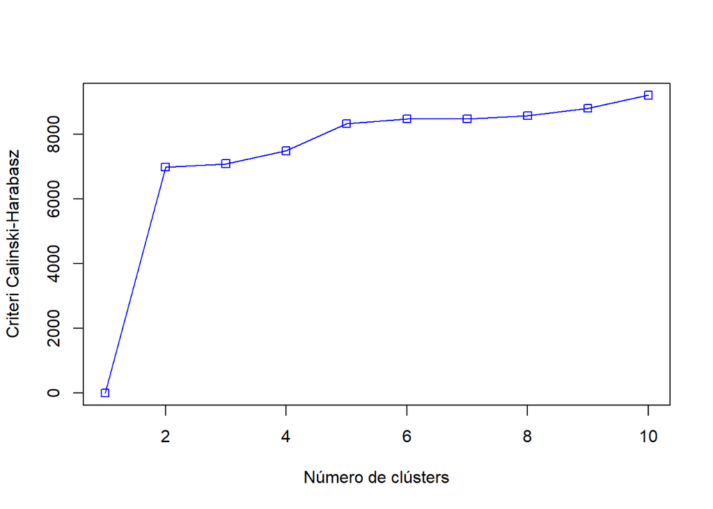

```r
plot(1:10,fit_ch$crit,type="o",col="blue",pch=0,xlab="Número de clústers",ylab="Criteri Calinski-Harabasz")
```

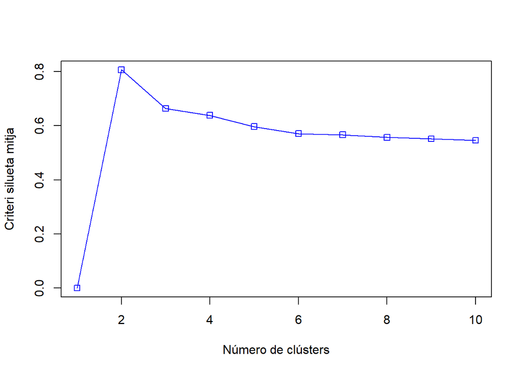

```r
plot(1:10,fit_asw$crit,type="o",col="blue",pch=0,xlab="Número de clústers",ylab="Criteri silueta mitja")
```

**Llegenda gràfic de classificació real**

- *Cooper’s*
- *Red-tailed*
- *Sharp-Shinned*

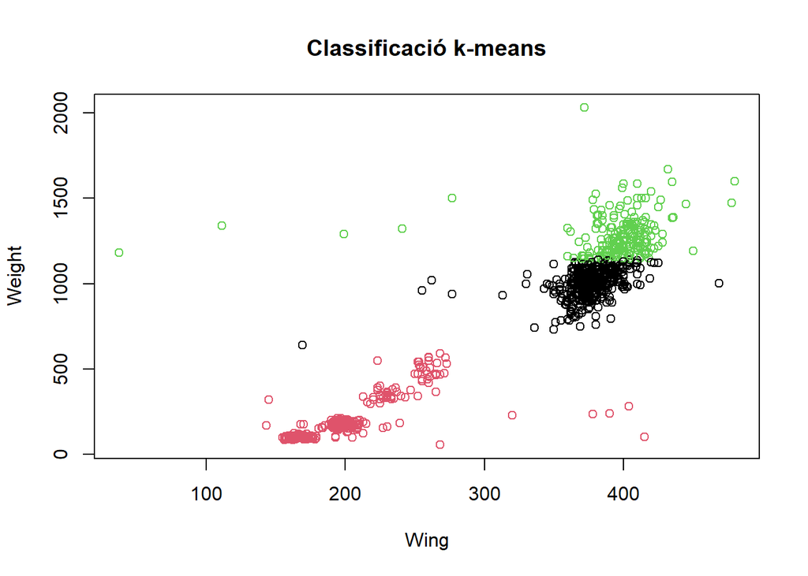

```r
hawks3clusters <- kmeans(x, 3)

plot(x[c(1,2)], col=hawks3clusters$cluster, main="Classificació k-means")
```

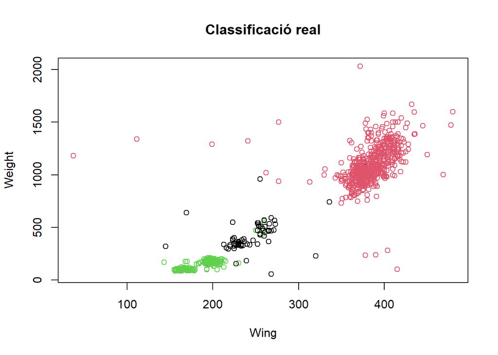

```r
plot(Hawks[c(10,11)], col=as.factor(Hawks$Species), main="Classificació real")
```

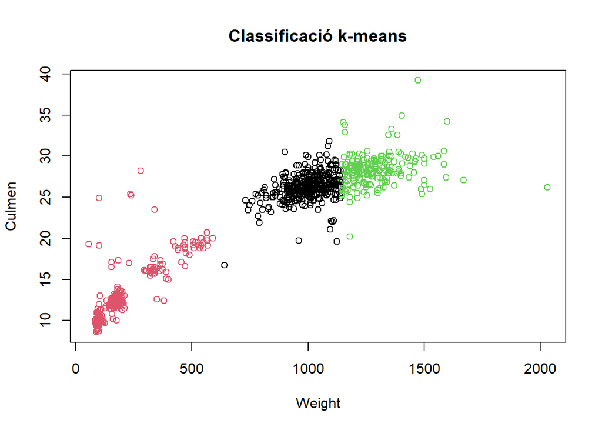

```r
plot(x[c(2,3)], col=hawks3clusters$cluster, main="Classificació k-means")
```

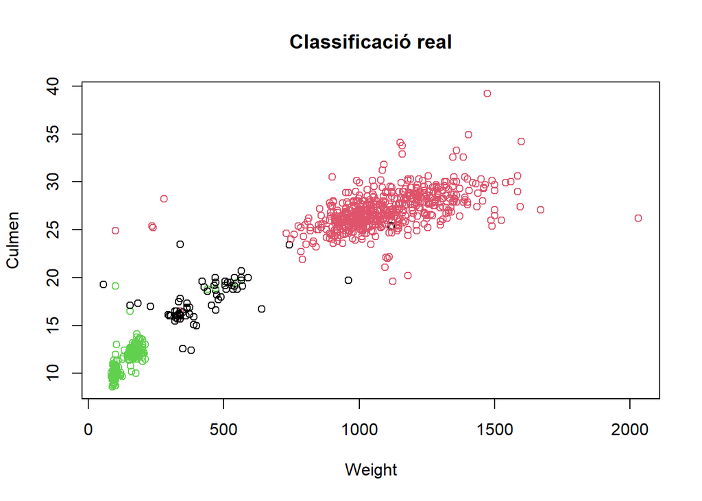

```r
plot(Hawks[c(11,12)], col=as.factor(Hawks$Species), main="Classificació real")
```

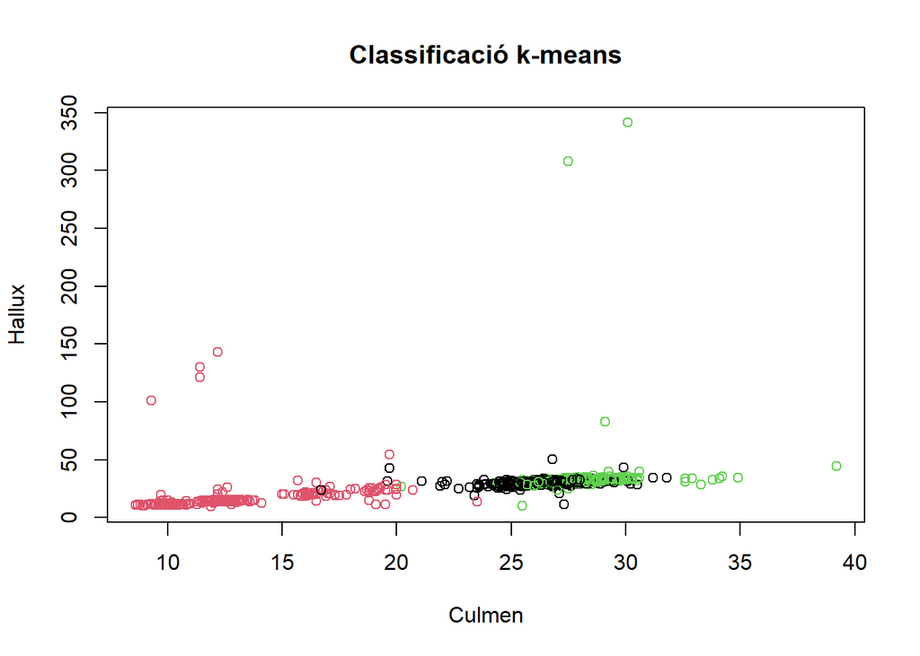

```r
plot(x[c(3,4)], col=hawks3clusters$cluster, main="Classificació k-means")
```

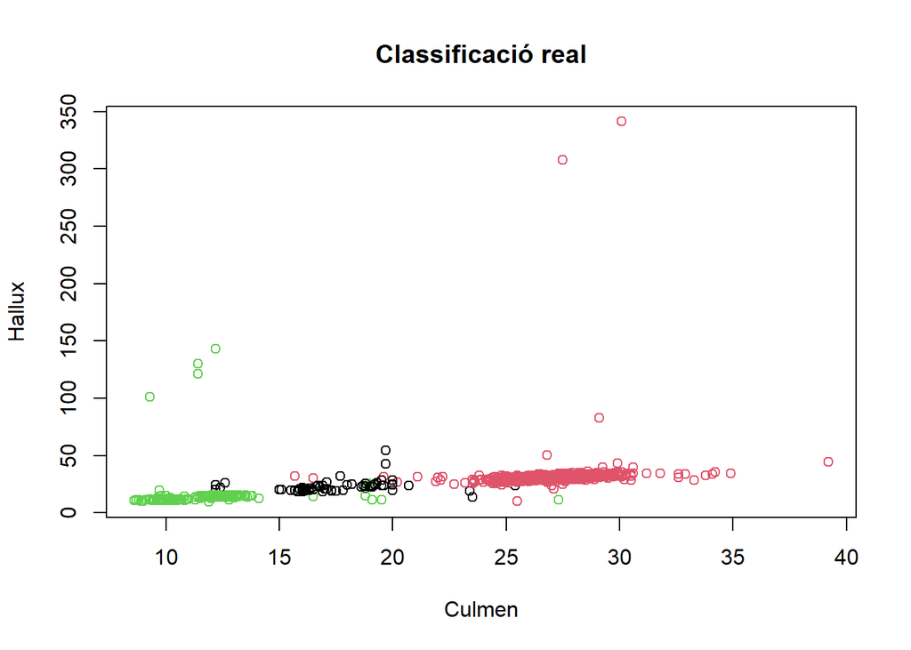

```r
plot(Hawks[c(12,13)], col=as.factor(Hawks$Species), main="Classificació real")
```

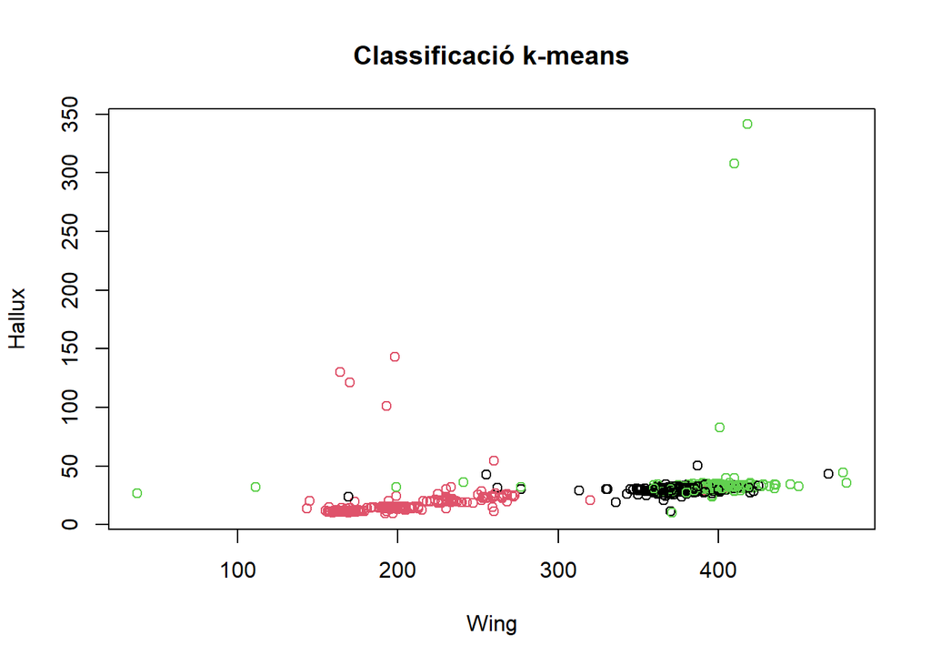

```r
plot(x[c(1,4)], col=hawks3clusters$cluster, main="Classificació k-means")
```

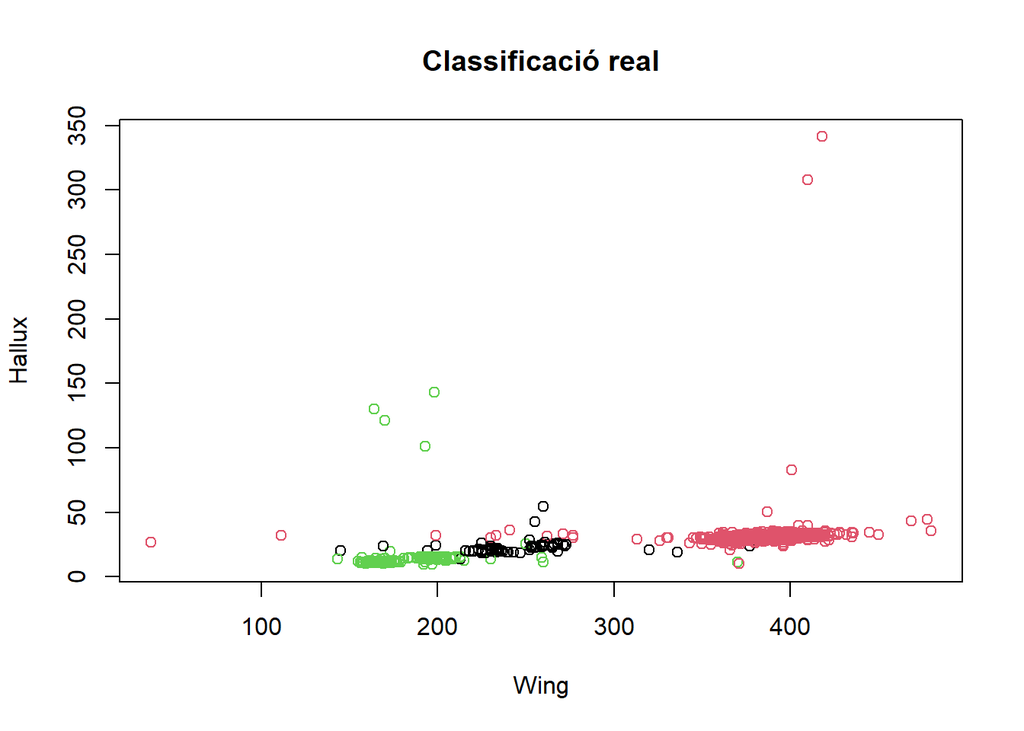

```r
plot(Hawks[c(10,13)], col=as.factor(Hawks$Species), main="Classificació real")
```

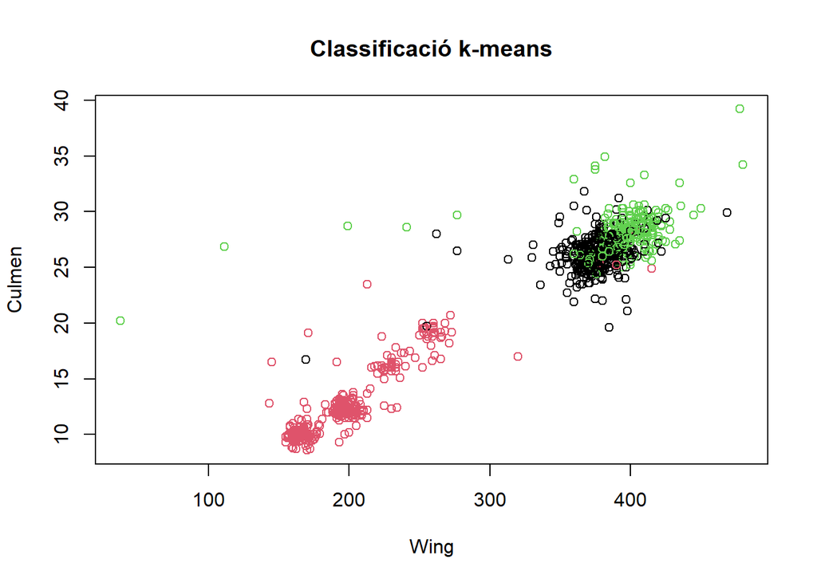

```r
plot(x[c(1,3)], col=hawks3clusters$cluster, main="Classificació k-means")
```

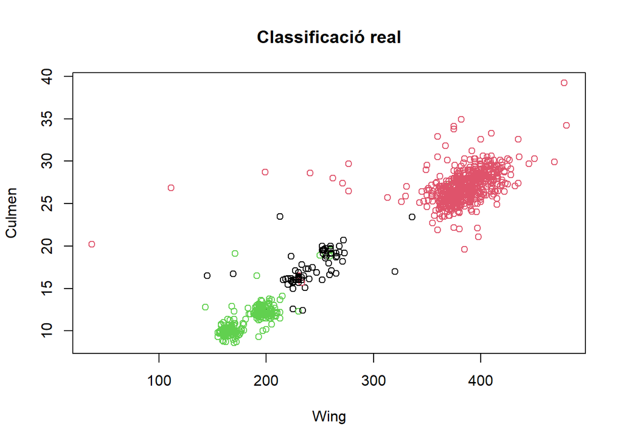

```r
plot(Hawks[c(10,12)], col=as.factor(Hawks$Species), main="Classificació real")
```

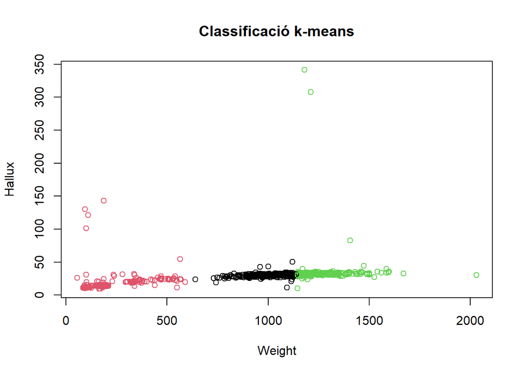

```r
plot(x[c(2,4)], col=hawks3clusters$cluster, main="Classificació k-means")
```

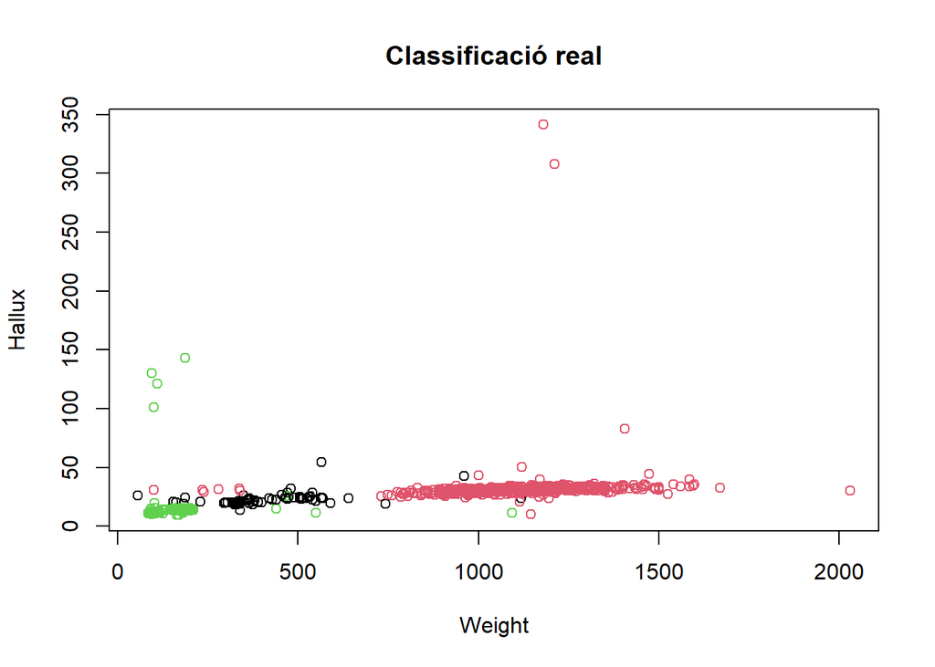

```r
plot(Hawks[c(11,13)], col=as.factor(Hawks$Species), main="Classificació real")
```

## 1.2 Resposta 2

En aquest apartat utilitzarem mètodes de *clustering* basats en la densitat. Concretament, els mètodes **DBSCAN** i **OPTICS**. Aquests mètodes es caracteritzen per identificar zones d’alta concentració o densitat d’observacions separades entre si per zones amb menor densitat. Aquests mètodes, com veureu a continuació, depenen de dos paràmetres: **èpsilon** (radi de veïnatge) i **minPts** (mínim nombre de punts o observacions veïns d’un punt dins del radi èpsilon). Encertar el valor d’aquests paràmetres pot resultar complex.

Comencem construint el joc de dades i mostrem un gràfic amb 3 zones ben diferenciades.

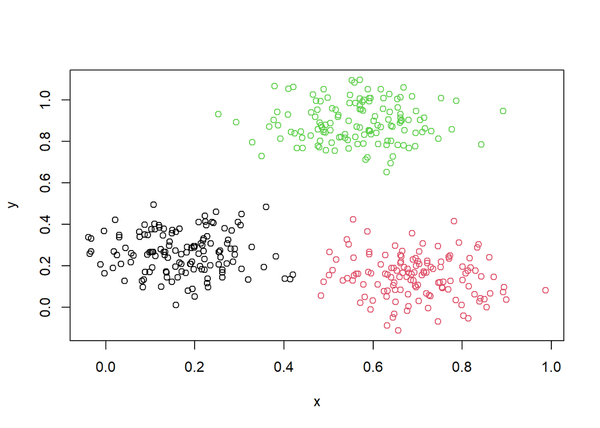

```r
if (!require('dbscan')) install.packages('dbscan'); library('dbscan')
set.seed(2)
n <- 400
x <- cbind(
x = runif(3, 0, 1) + rnorm(n, sd=0.1),
y = runif(3, 0, 1) + rnorm(n, sd=0.1)
)
plot(x, col=rep(1:3, time = 100))
```

### 1.2.1 OPTICS

**OPTICS** (*Ordering points to identify cluster structure*) generalitza DBSCAN i soluciona l’inconvenient dels paràmetres inicials. A la pràctica, aquest algoritme no genera una proposta de clústers a partir d’un joc de dades, sinó que **ordena** els punts en funció de la seva **distància d’associabilitat**. Per això, el gràfic més interessant i que millor pot il·lustrar aquest algorisme és el *reachability plot* o gràfic d’associabilitat.

Modificant els paràmetres es pot calibrar la distància d’associabilitat límit del que volem considerar un clúster.

Per tant, el primer que farem serà ordenar els punts.

```r
### Executem l'algoritme OPTICS deixant el paràmetre eps amb el seu valor per defecte i fixant el criteri de veïnatge en 10
res <- optics(x, minPts = 10)
res
```

```
## OPTICS ordering/clustering for 400 objects.
## Parameters: minPts = 10, eps = 0.197070882836578, eps_cl = NA, xi = NA
## Available fields: order, reachdist, coredist, predecessor, minPts, eps,
##                   eps_cl, xi
```

```r
### Obtenim la ordenació de les observacions o punts
res$order
```

```
##   [1]   1 367 370 349 391 358 343 322 295 208 178   4 235 190 100 133 304 400
##  [19] 382 373 328 283 250 229 223 319 253 175 211 292 232 121  49  10 364 361
##  [37] 307 139 394 220 118 109  97  79  43  64 310 313  58  85 217 199 112   7
##  [55]  37 115  73 169 274 241 106 256 145 337 286  91  61 289 247 352 334 157
##  [73] 148  13 331  34  70 385 298 340 301 163 160 136 172 166 124 103 226  31
##  [91] 325  88 214 346 355 268  52 187  22 202  67  40 388 316 205  82  55  16
## [109] 151 277 193  19 244 280 238 127 154 196  94 184 262 181  25 265 130  46
## [127] 259  76 376 271 379 142  28 397 299 392 302 293 236 212 191 386 380 353
## [145] 275 221 116  89  59  41  32  50 305  53 389 359 347 341 311 113  35 182
## [163]  74   8 158 149 143 137  56 245  17  47 371 179 203 119  23 383 281 242
## [181] 368 356 104  98  77  44 131 251 224  95 194 314  20 344 200 398 365 263
## [199] 257 146 395 254 233  29 287 218 170  92 317 134  71 323  62 197  11 290
## [217]  14 125 209 284 167 152 272 185 350 338  65 269 176 377 335 374 278  86
## [235]  80 248   2  68 173 227 215 140 110  83  26 122 161 266 296 101 239  38
## [253] 320 206 128 155 107 230 308 332 260 326   5 329 188 362 164   3 360 204
## [271] 102 279  93  81  72 348 297 192  57  27  24 186 285 291 276 213 132 129
## [289]  39  33  12  42 264 237 372 327 315 282 258 216 144  75 390 306 321 162
## [307] 159  78  15 375 342 369 357 324 318 180 138  96  60  36  54 300 387 120
## [325]  63 381 294 153  48 393 183 207 195 135 255 243 330 384 231 174 168 150
## [343] 219 123 105  90  69  45 222 249  18 117 252 141 267 177 303 273 201   9
## [361] 261  99  21 396   6 234 165 114 111  87 147  51 366 198 378  30 270 228
## [379] 351 189 240 339 156  84 171 354 312 225 333 399 288  66 345 126 108 336
## [397] 246 309 210 363
```

A partir d’aquesta ordenació, podem generar l’esmentat gràfic d’associativitat. En aquest, podem observar les distàncies d’associativitat de cadascun dels punts. Les valls representen els punts més interiors dels clústers i els cims són els valors *outliners* o que es troben en zones poc denses entre clústers. Cal destacar que com més ample és la vall, més dens és el clúster, perquè més observacions es troben a prop d’aquests.

També afegim un gràfic per veure les traces de les distàncies entre punts.

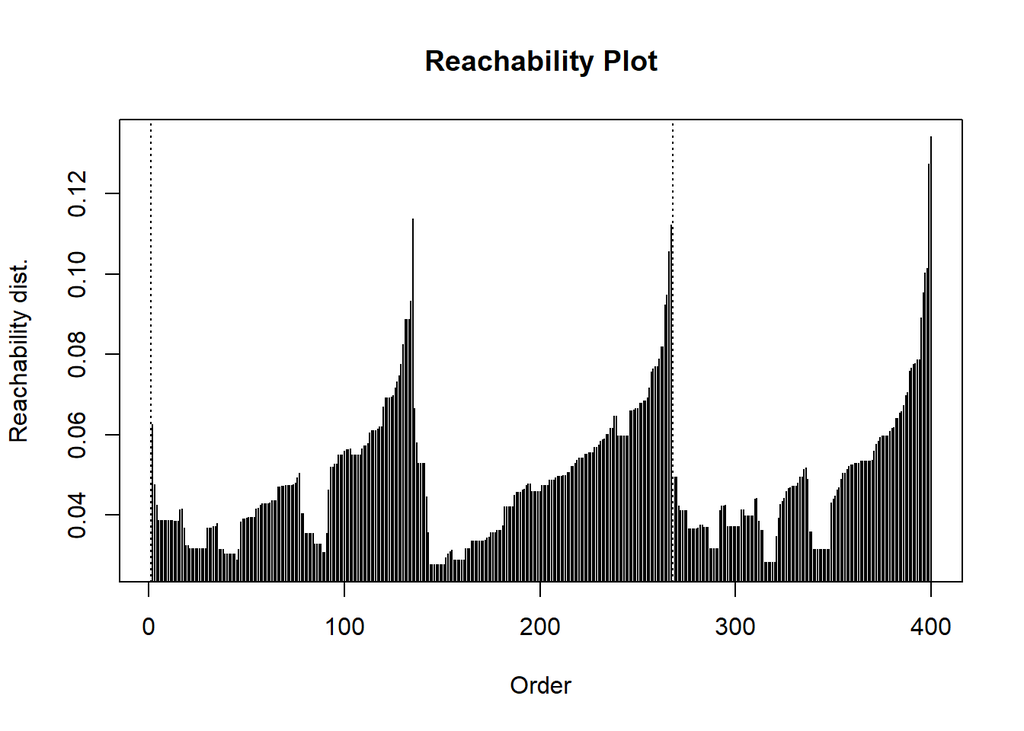

```r
### Gràfic d'accessibilitat
plot(res)
```

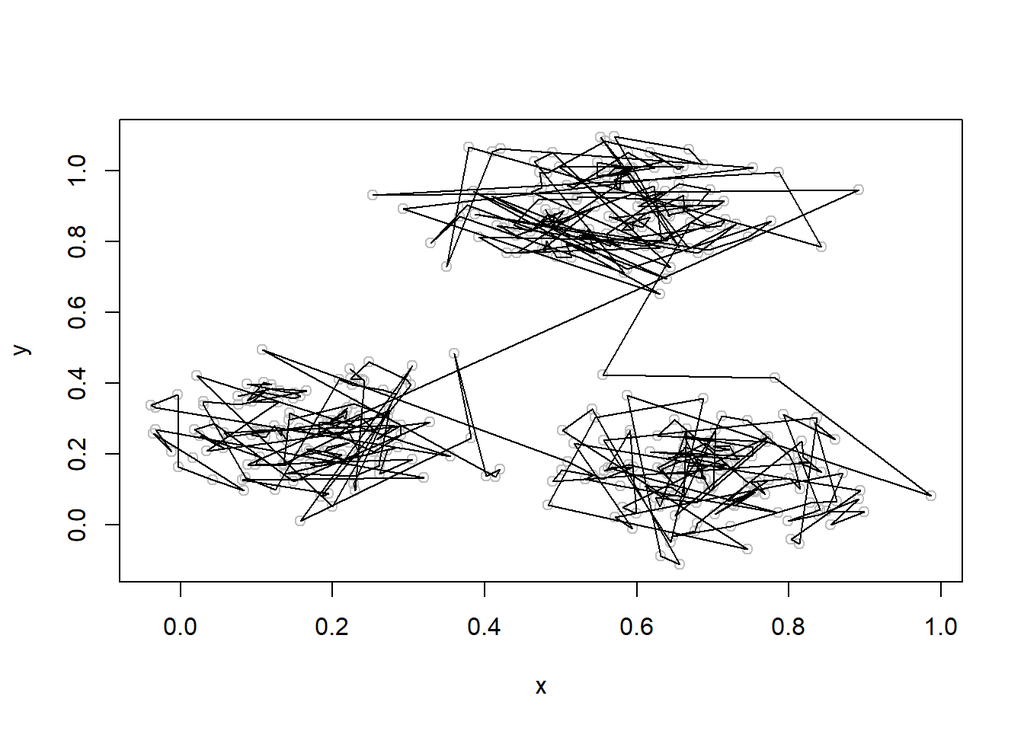

```r
### Dibuixem les traces que relacionen punts
plot(x, col = "grey")
polygon(x[res$order,])
```

### 1.2.2 DBSCAN

A continuació, experimentarem amb èpsilon (radi de veïnatge) utilitzant l’algoritme **DBSCAN**. Això limitarà la distància límit d’accessibilitat i canviarà els resultats obtinguts.

```r
res <- extractDBSCAN(res, eps_cl = .065)
res
```

```
## OPTICS ordering/clustering for 400 objects.
## Parameters: minPts = 10, eps = 0.197070882836578, eps_cl = 0.065, xi = NA
## The clustering contains 3 cluster(s) and 55 noise points.
##
##   0   1   2   3
##  55 119 110 116
##
## Available fields: order, reachdist, coredist, predecessor, minPts, eps,
##                   eps_cl, xi, cluster
```

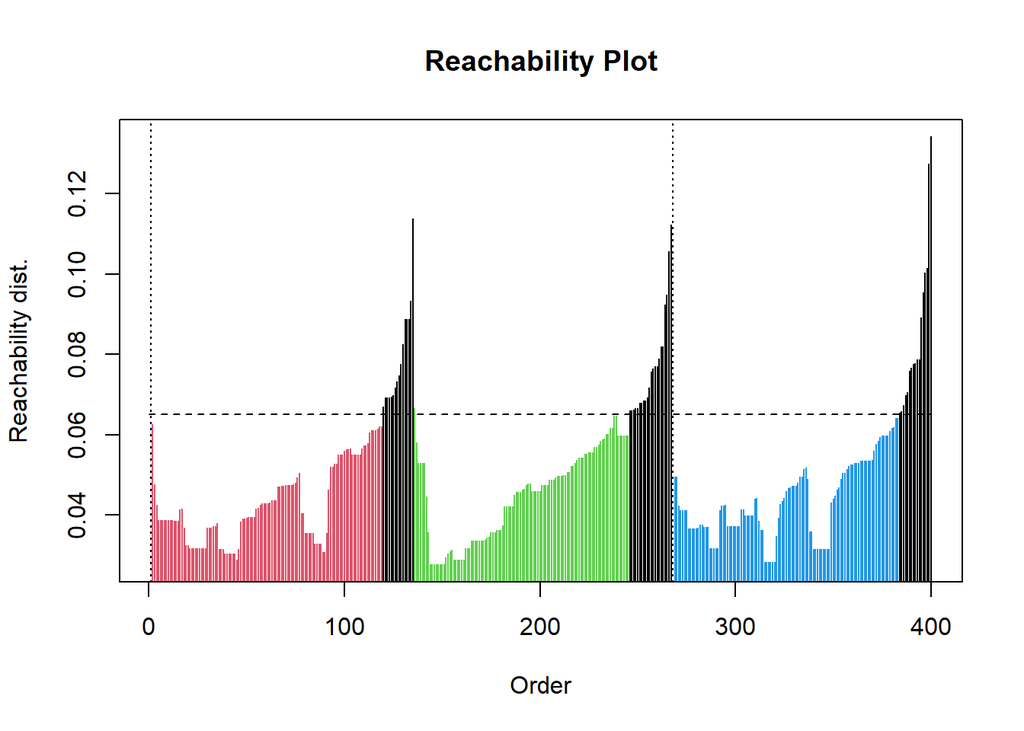

```r
plot(res) ## negre indica soroll
```

A continuació, mostrarem els clústers en formes convexes.

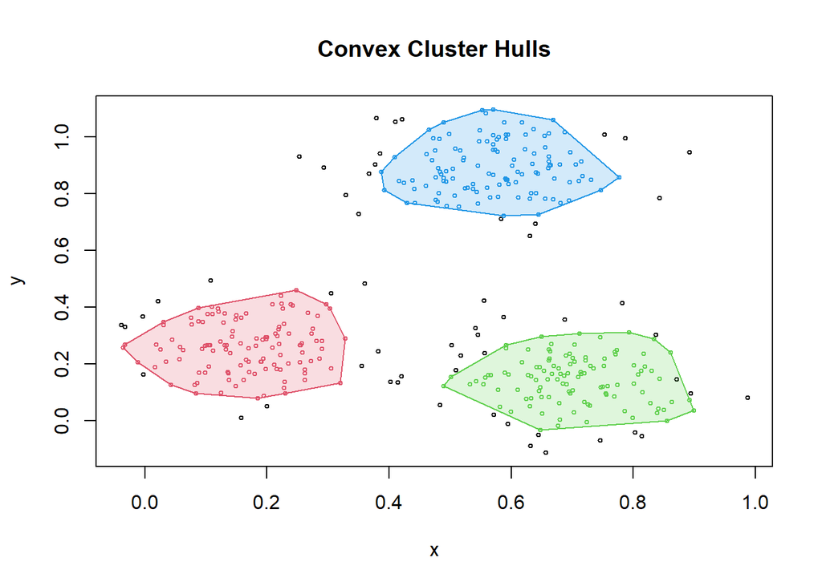

```r
hullplot(x, res)
```

Com és d’imaginar, si pugem el límit hi haurà menys valors *outliners*, i el mateix a l’inrevés.

Per exemple:

```r
# Baixem a 0.05 eps
res <- extractDBSCAN(res, eps_cl = .05)
res
```

```
## OPTICS ordering/clustering for 400 objects.
## Parameters: minPts = 10, eps = 0.197070882836578, eps_cl = 0.05, xi = NA
## The clustering contains 5 cluster(s) and 150 noise points.
##
##   0   1   2   3   4   5
## 150  75  16  73  67  19
##
## Available fields: order, reachdist, coredist, predecessor, minPts, eps,
##                   eps_cl, xi, cluster
```

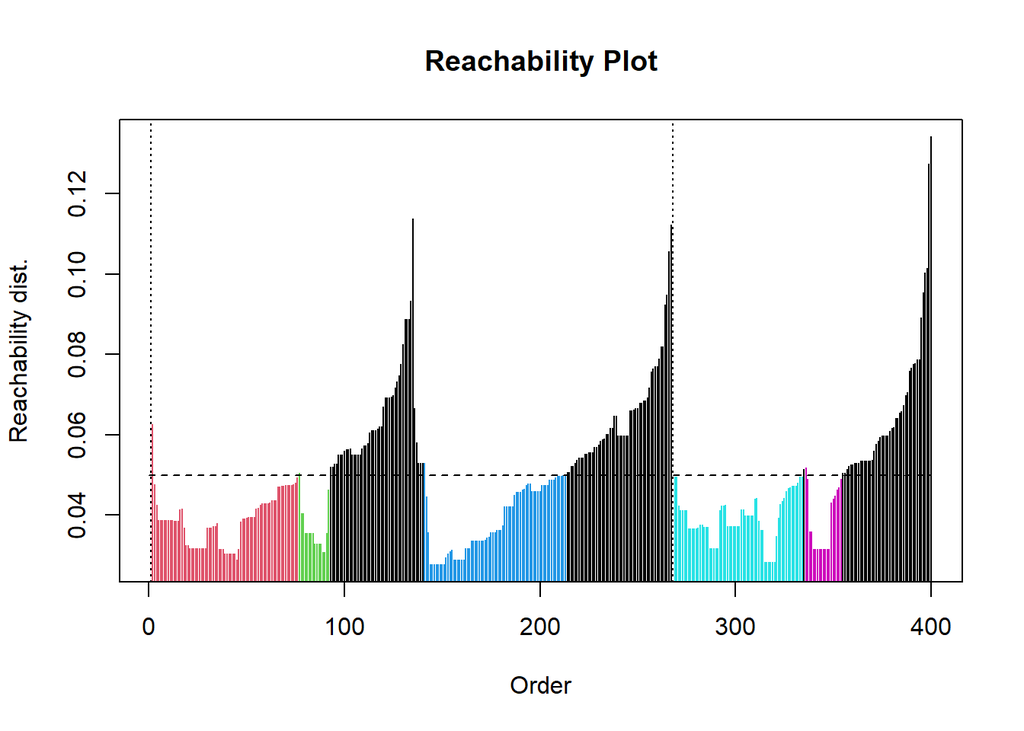

```r
plot(res)
```

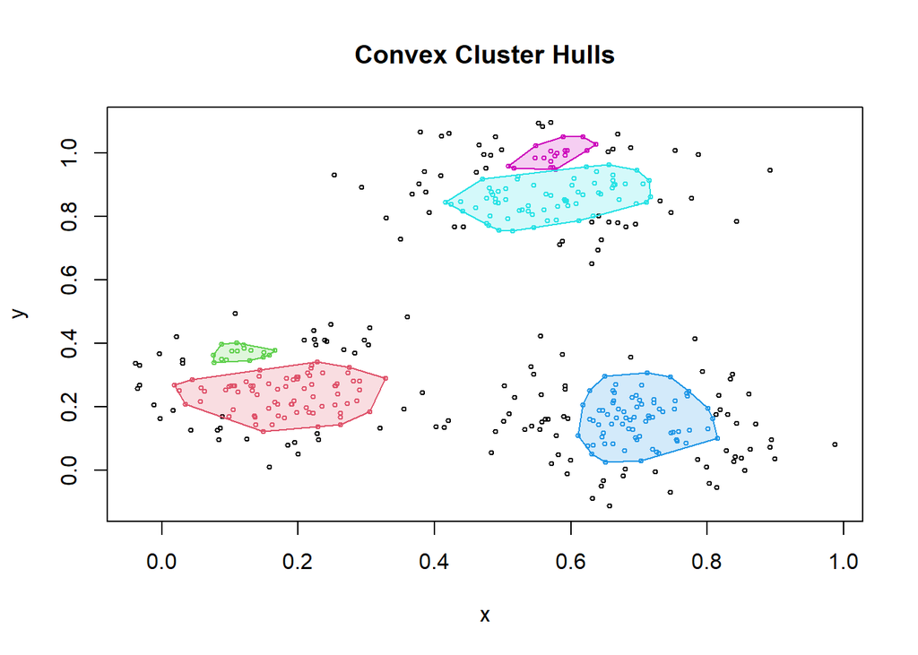

```r
hullplot(x, res)
```

```r
# Pujem a 0.12 eps
res <- extractDBSCAN(res, eps_cl = .12)
res
```

```
## OPTICS ordering/clustering for 400 objects.
## Parameters: minPts = 10, eps = 0.197070882836578, eps_cl = 0.12, xi = NA
## The clustering contains 2 cluster(s) and 2 noise points.
##
##   0   1   2
##   2 267 131
##
## Available fields: order, reachdist, coredist, predecessor, minPts, eps,
##                   eps_cl, xi, cluster
```

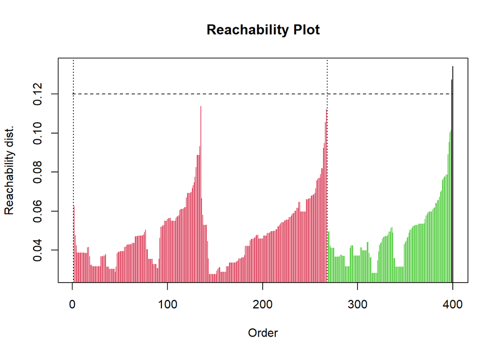

```r
plot(res)
```

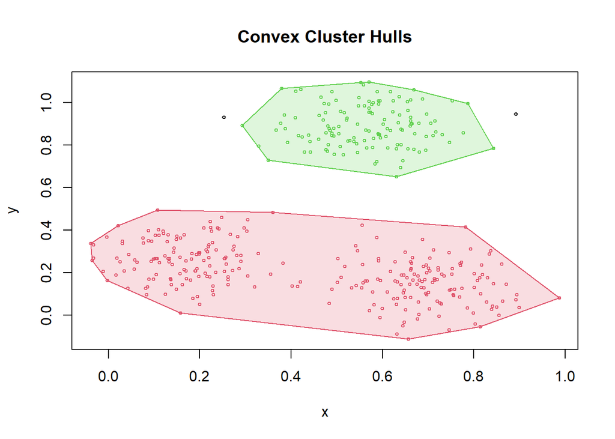

```r
hullplot(x, res)
```

Aquests dos experiments han resultat veritablement interessants.

D’altra banda, quan l’hem pujat, hem obtingut únicament 2 punts de soroll i s’han agrupat les observacions en 2 únics clústers. Com més alts són els cims o punts de soroll, major ha de ser el límit d’accessibilitat perquè les observacions passin a formar part del mateix clúster.

Vegem ara una variant de DBSCAN. El valor xi ens permetrà visualitzar els clústers en funció del canvi en la densitat relativa d’aquests.

```r
### Extracció del clustering jeràrquic en funció de la variació de la densitat pel mètode xi
res <- extractXi(res, xi = 0.05)
res
```

```
## OPTICS ordering/clustering for 400 objects.
## Parameters: minPts = 10, eps = 0.197070882836578, eps_cl = NA, xi = 0.05
## The clustering contains 7 cluster(s) and 2 noise points.
##
## Available fields: order, reachdist, coredist, predecessor, minPts, eps,
##                   eps_cl, xi, cluster, clusters_xi
```

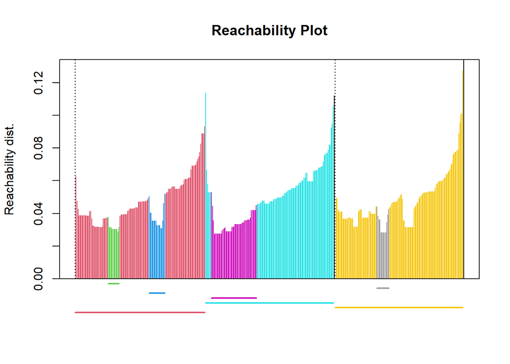

```r
plot(res)
```

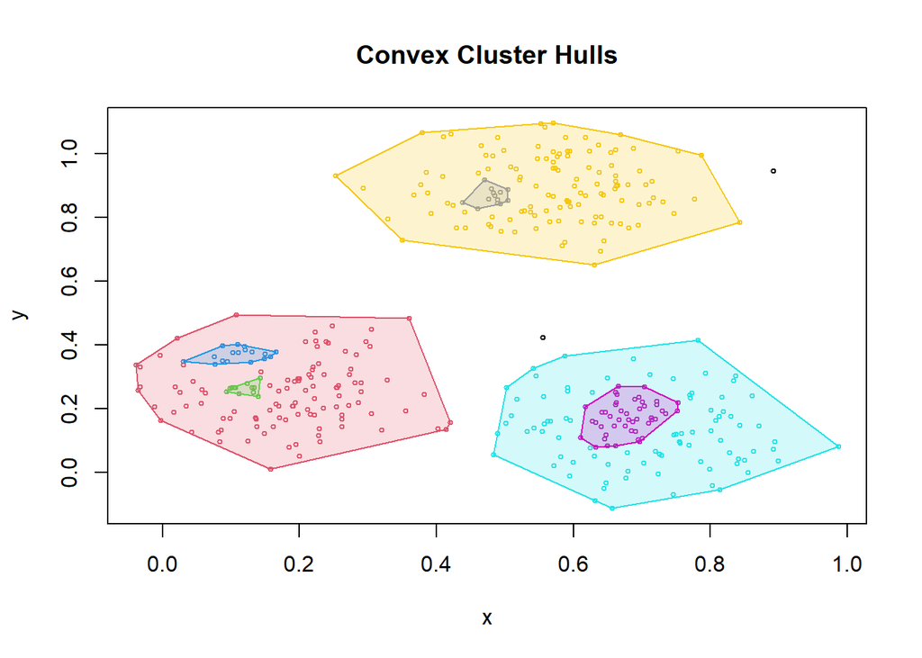

```r
hullplot(x, res)
```

# 2 Exercici 3

Realitza una comparativa dels mètodes *k-means* i *DBSCAN*

## 2.1 Resposta 3

Tant k-means com DBSCAN són dos models de classificació no supervisada basats molt interessants i poden resultar molt útils per classificar observacions basant-se en les seves característiques.

D’altra banda, k-means té el gran inconvenient que s’ha d’indicar el nombre de clústers abans d’executar l’algoritme, pel que encertar el nombre correcte pot portar uns quants intents.

En conclusió, no hem aconseguit que el model **k-means** classifiqui les observacions per espècie correctament. Això és probablement degut a l’aleatorietat dels centroides inicials, ja que en alguna de les execucions en el transcurs de la redacció d’aquesta pràctica sí que ha sigut capaç de classificar les espècies correctament. Respecte al mètode basat en densitat DBSCAN s’ha assolit tenir tres clústers molt diferenciats i he jugat amb el valor èpsilon per a calibrar el límit d’accessibilitat.